Matplotlib is a commonly used visualization package embedded in Python. In recent years, however, the interface and style of Matplotlib have begun to show their age. Newer tools like ggplot and ggvis in the R language, along with web visualization toolkits based on D3js and HTML5 canvas, often make Matplotlib feel clunky and old-fashioned. Other data visualization tools include PowerBI for business data analysis, Boken, Seaborn, ggpy for interactive data visualization are gradually adopted by data scientists to be used on a daily basis.

This work collects some commonly used templates for creating visualizations using Matplotlib and Seaborn.

# Matplotlib

strength： a well-tested, cross-platform graphics engine

weakness: clunky and old-fashioned compared to newer packages

```python
import matplotlib as mpl
import matplotlib.pyplot as plt
import numpy as np
%matplotlib inline
```

## Change default plotting style

https://matplotlib.org/tutorials/introductory/customizing.html

```python
print(plt.style.available) # list all available styles
```

[output not shown]

```python
plt.style.use('classic')

font = {'family': 'normal',
        'weight': 'normal',
        'size': 22}

mpl.rc('font', **font)
mpl.rcParams["figure.figsize"] = [12,8]
mpl.rcParams['lines.linewidth'] = 2
```

```python
# plt.style.use('ggplot')
# plt.rcParams.update({'font.size': 18.0,
#                      'xtick.labelsize': 18.0,
#                      'ytick.labelsize': 18.0,
#                      'axes.labelsize': 18.0})
```

## Line plots

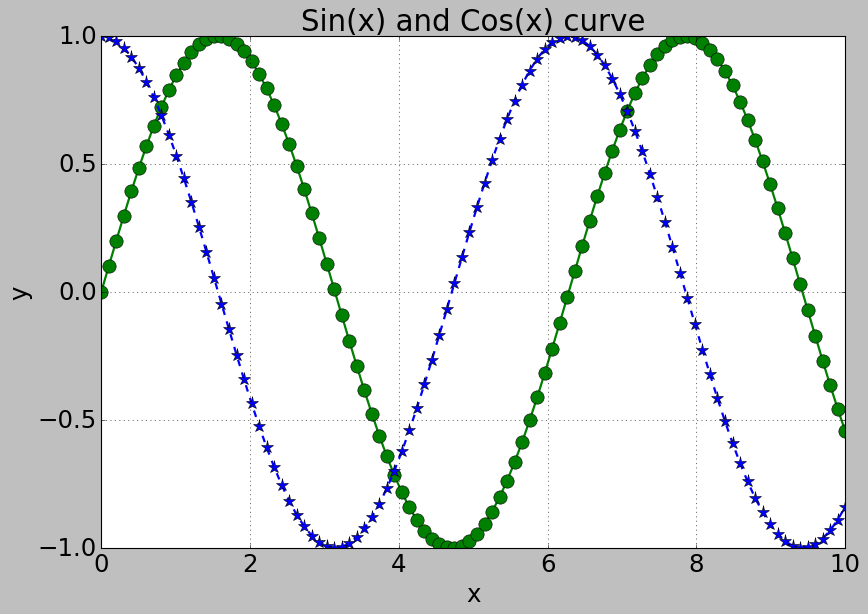

```python
x = np.linspace(0, 10, 100)

#plt.figure(figsize=(12,8))
plt.title('Sin(x) and Cos(x) curve')

plt.plot(x, np.sin(x), '-', marker='o', markersize=12, linewidth=2,  c='g')
plt.plot(x, np.cos(x), '--', marker='*',markersize=12, linewidth=2,  c='b')
# plt.xticks(old_ticklabel, new_ticklabel, rotation = 15) change tick labels
plt.xlabel('x')
plt.ylabel('y')
plt.grid(True)

plt.show()

# maker: https://matplotlib.org/api/markers_api.html, o, *, ^， v, <, >, 1-8
# plot line style: https://matplotlib.org/gallery/lines_bars_and_markers/line_styles_reference.html   :, -., --, -
```

## Scatter plots

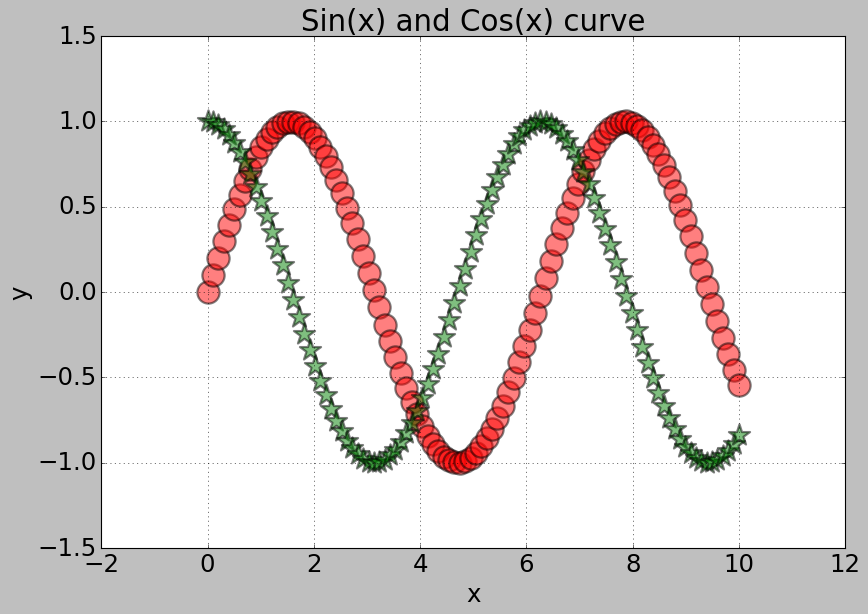

```python
x = np.linspace(0, 10, 100)

#plt.figure(figsize=(12,8))
plt.title('Sin(x) and Cos(x) curve')

plt.scatter(x, np.sin(x), s = 400, marker='o', linewidth=2,  c='r', alpha = 0.5) # s = size in points^2
plt.scatter(x, np.cos(x), s = 400, marker='*', linewidth=2,  c='g', alpha = 0.5)
# plt.xticks(old_ticklabel, new_ticklabel, rotation = 15) change tick labels
plt.xlabel('x')
plt.ylabel('y')
plt.grid(True)

plt.show()
```

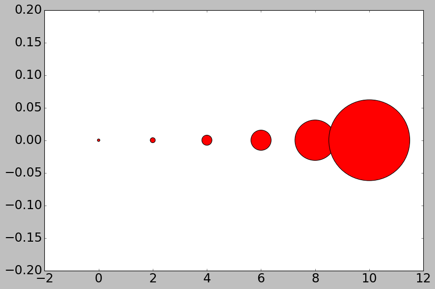

```python
# adjust scatter plot marker size

x = [0, 2, 4, 6, 8, 10]
y = [0]*len(x)

s = [20*4**n for n in range(len(x))]
plt.scatter(x, y, s=s, c='r')
plt.show()
```

## Bar plots

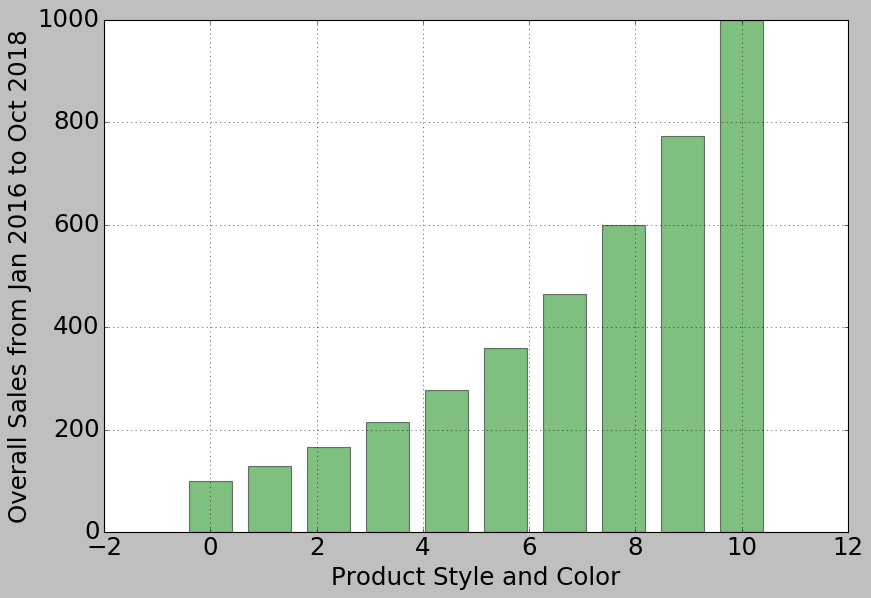

```python
x = np.linspace(0, 10, 10)
y = np.logspace(2.0, 3.0, 10)

#plt.figure(figsize=(12,8))
plt.bar(x, y, align = 'center', alpha=0.5, color = 'g')
# plt.xticks(x, label, rotation = 30)
plt.xlabel('Product Style and Color')
plt.ylabel('Overall Sales from Jan 2016 to Oct 2018')
plt.grid(True)
plt.show()

# color: https://matplotlib.org/api/_as_gen/matplotlib.pyplot.colors.html
# b, g, r, c, m, y, k, w
```

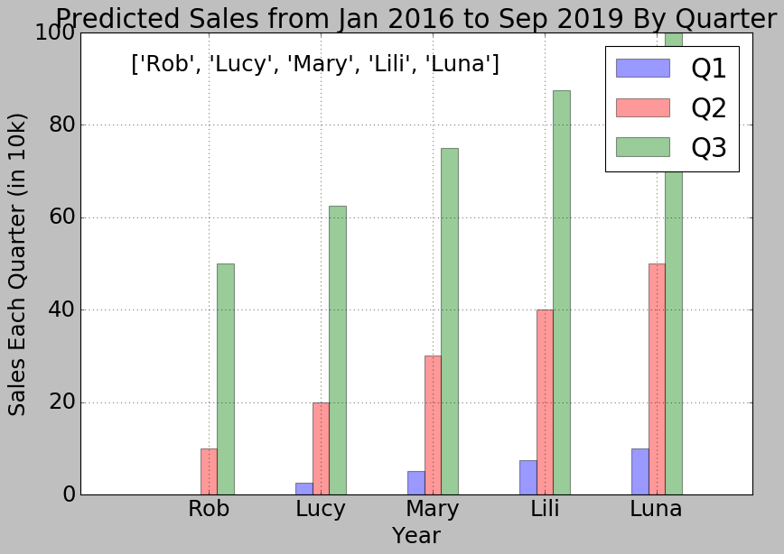

```python
fig, ax = plt.subplots()
plt.figure(figsize=(12,8))
bar_width = 0.15
index = np.arange(5)
label = ['Rob', 'Lucy', 'Mary', 'Lili', 'Luna']
Q1 = np.linspace(0, 10, 5)
Q2 = np.linspace(10, 50, 5)
Q3 = np.linspace(50, 100, 5)

opacity = 0.4
q1 = ax.bar(index, Q1, bar_width, alpha=opacity, color='b', label='Q1')
q2 = ax.bar(index + bar_width, Q2, bar_width, alpha=opacity, color='r', label='Q2')
q3 = ax.bar(index + bar_width*2, Q3, bar_width, alpha=opacity, color='g', label='Q3')

ax.set_xlabel('Year')
ax.set_ylabel('Sales Each Quarter (in 10k)')
ax.set_title('Predicted Sales from Jan 2016 to Sep 2019 By Quarter')
ax.set_xticks(index + bar_width)
ax.set_xticklabels(label)
ax.legend()
ax.text(0.35, 0.93, label, ha='center', va='center',transform=ax.transAxes)

ax.grid(True)
plt.show()
```

## Pie graph

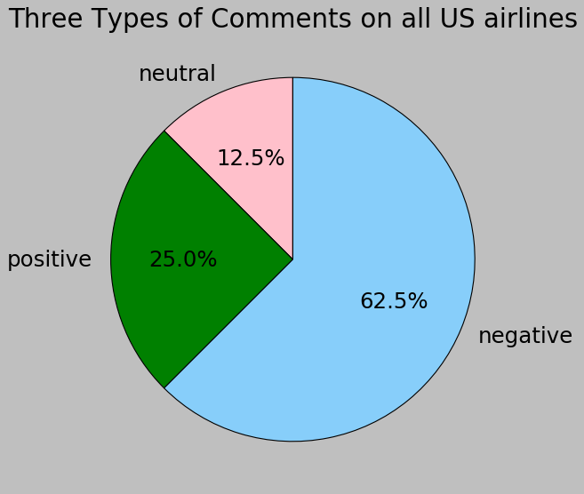

```python
sizes = [100, 200, 500]
colors = ['pink', 'green', 'lightskyblue']
labels = ['neutral', 'positive', 'negative']

plt.pie(sizes, labels=labels, colors=colors, autopct="%1.1f%%", startangle = 90)
plt.title('Three Types of Comments on all US airlines')
plt.show()
```

## Multiple plots in one figure

MATLAB style, easy to plot but difficult to make changes once the data is plotted. plt.plot()

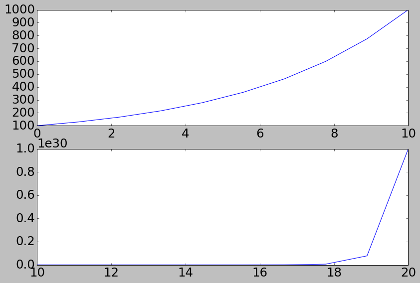

```python
x1 = np.linspace(0, 10, 10)
y1 = np.logspace(2.0, 3.0, 10)

x2 = np.linspace(10, 20, 10)
y2 = np.logspace(20, 30, 10)

plt.figure(figsize=(12,8))
#
# create the first plot
plt.subplot(211)
plt.plot(x1, y1)

# create the second plot
plt.subplot(212)
plt.plot(x2, y2)
```

Object-oriented interface: more control over the figure ax.plot()

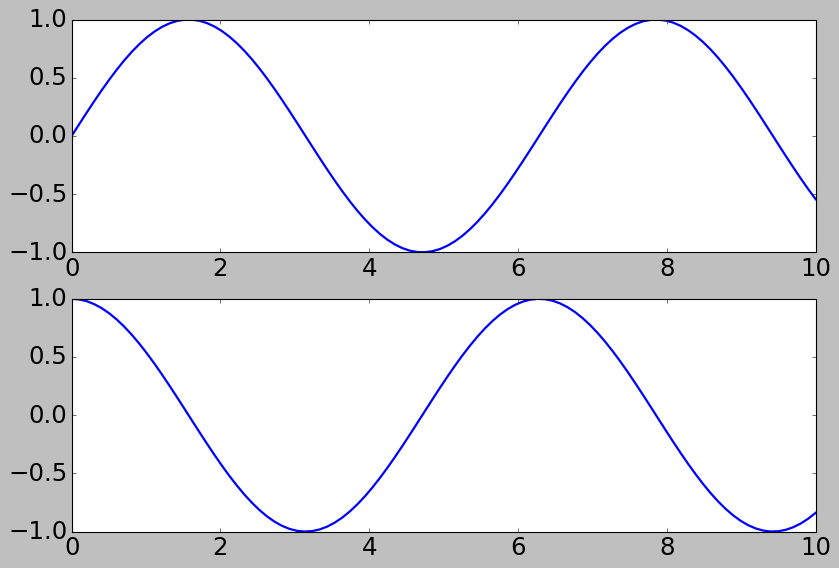

```python
# first create a grid of plots, ax will be an array of two Axes objects
fig, ax = plt.subplots(2)

# call plot() method on the appropriate object
ax[0].plot(x, np.sin(x))
ax[1].plot(x, np.cos(x))
```

## Save Figure

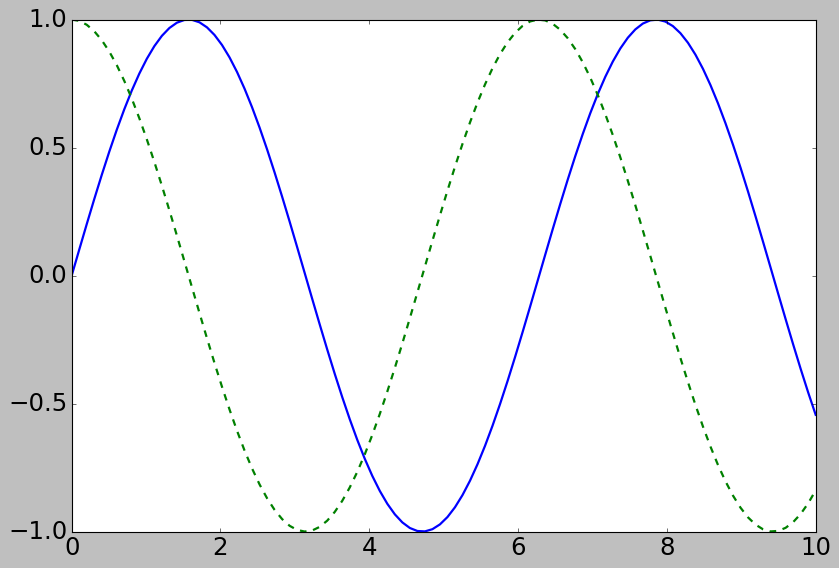

```python
x = np.linspace(0, 10, 100)

fig = plt.figure()
plt.plot(x, np.sin(x), '-')
plt.plot(x, np.cos(x), '--')
```

```python
# fig.savafig('my_figure.png')
```

```python
fig.canvas.get_supported_filetypes()
```

```
{'ps': 'Postscript',
 'eps': 'Encapsulated Postscript',
 'pdf': 'Portable Document Format',
 'pgf': 'PGF code for LaTeX',
 'png': 'Portable Network Graphics',
 'raw': 'Raw RGBA bitmap',
 'rgba': 'Raw RGBA bitmap',
 'svg': 'Scalable Vector Graphics',
 'svgz': 'Scalable Vector Graphics',
 'jpg': 'Joint Photographic Experts Group',
 'jpeg': 'Joint Photographic Experts Group',
 'tif': 'Tagged Image File Format',
 'tiff': 'Tagged Image File Format'}
```

# Seaborn for Interactive Graphing

```python
import seaborn as sns
import pandas as pd
import numpy as pd
```

```python
dataset = sns.load_dataset('titanic')
```

```python
dataset.head()
```

|  | survived | pclass | sex | age | sibsp | parch | fare | embarked | class | who | adult_male | deck | embark_town | alive | alone |
| --- | --- | --- | --- | --- | --- | --- | --- | --- | --- | --- | --- | --- | --- | --- | --- |
| 0 | 0 | 3 | male | 22.0 | 1 | 0 | 7.2500 | S | Third | man | True | NaN | Southampton | no | False |
| 1 | 1 | 1 | female | 38.0 | 1 | 0 | 71.2833 | C | First | woman | False | C | Cherbourg | yes | False |
| 2 | 1 | 3 | female | 26.0 | 0 | 0 | 7.9250 | S | Third | woman | False | NaN | Southampton | yes | True |
| 3 | 1 | 1 | female | 35.0 | 1 | 0 | 53.1000 | S | First | woman | False | C | Southampton | yes | False |
| 4 | 0 | 3 | male | 35.0 | 0 | 0 | 8.0500 | S | Third | man | True | NaN | Southampton | no | True |

## Dist Plot

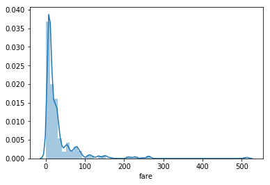

```python
sns.distplot(dataset['fare'])
```

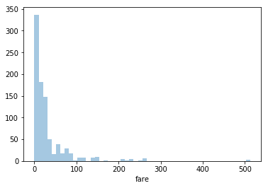

```python
sns.distplot(dataset['fare'], kde = False)
```

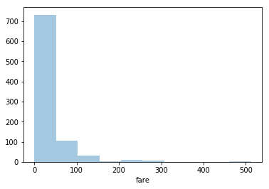

```python
sns.distplot(dataset['fare'], kde = False, bins = 10)
```

## Joint Plot

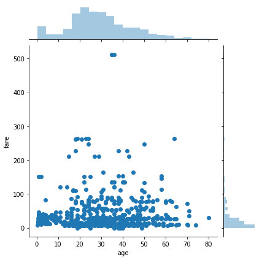

```python
sns.jointplot(x='age', y='fare', data=dataset)
```

hexagonal plot

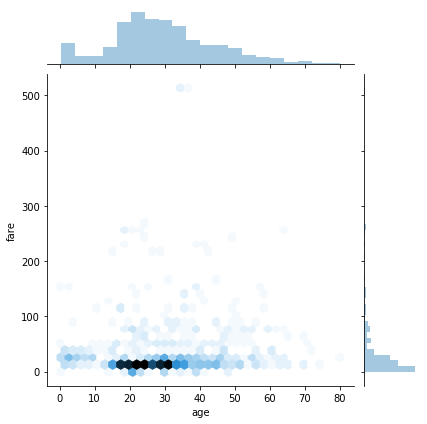

```python
sns.jointplot(x='age', y='fare', data=dataset, kind='hex')
```

## Pair Plot

```python
dataset = dataset.dropna()
```

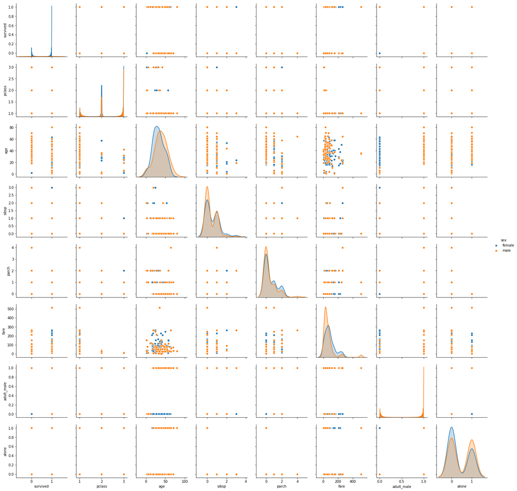

```python
sns.pairplot(dataset, hue='sex') # separate by gender
```

## Rug Plot

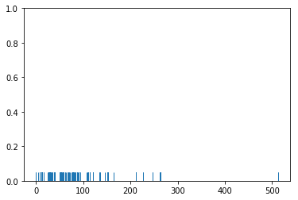

```python
sns.rugplot(dataset['fare'])
```

## Bar Plot

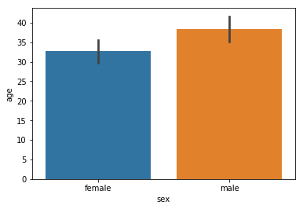

```python
sns.barplot(x='sex', y='age', data=dataset)
```

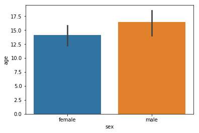

```python
import numpy as np
sns.barplot(x='sex', y='age', data=dataset, estimator = np.std)
```

## Count Plot

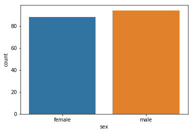

```python
sns.countplot(x='sex', data=dataset)
```

## Box Plot

The box plot is used to display the distribution of the categorical data in the form of quartiles. The center of the box shows the median value. The value from the lower whisker to the bottom of the box shows the first quartile. From the bottom of the box to the middle of the box lies the second quartile. From the middle of the box to the top of the box lies the third quartile and finally from the top of the box to the top whisker lies the last quartile.

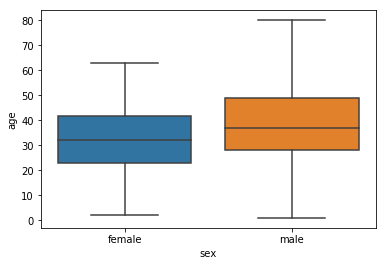

```python
sns.boxplot(x='sex', y='age', data=dataset)
```

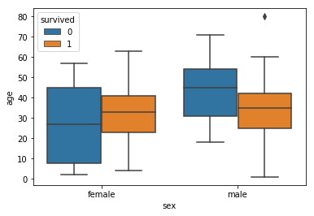

```python
sns.boxplot(x='sex', y='age', data=dataset, hue="survived")
```

## Violin Plot

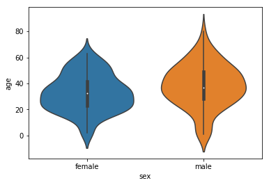

```python
sns.violinplot(x='sex', y='age', data=dataset)
```

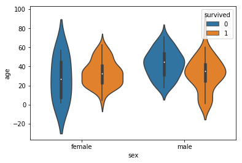

```python
sns.violinplot(x='sex', y='age', data=dataset, hue='survived')
```

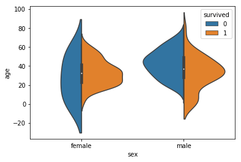

```python
sns.violinplot(x='sex', y='age', data=dataset, hue='survived', split=True)
```

## Strip Plot

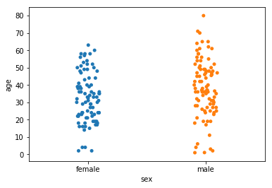

```python
sns.stripplot(x='sex', y='age', data=dataset, jitter=True)
```

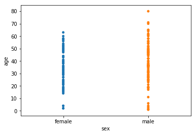

```python
sns.stripplot(x='sex', y='age', data=dataset, jitter=False)
```

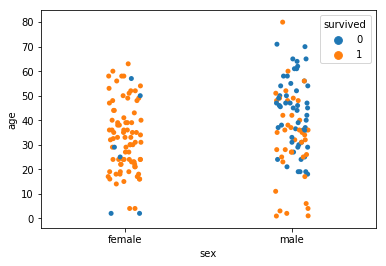

```python
sns.stripplot(x='sex', y='age', data=dataset, jitter=True, hue='survived')
```

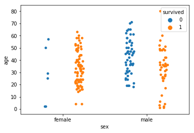

```python
sns.stripplot(x='sex', y='age', data=dataset, jitter=True, hue='survived', split=True)
```

Interactive visualization using Seaborn to be explored.